# Pre-oligotyping diagnostics for functional genes

Marina Zure and Antonio Fernandez-Guerra

February 29, 2016

**How to decide if we should keep the third codon position if we want to perform a oligotyping analysis on functional genes**

In this examples the files are used to perform a Minimum Entropy Decomposition ([MED](http://merenlab.org/projects/med/)) analysis, the unsupervised flavour for [oligotyping](http://merenlab.org/projects/oligotyping/).

First we load the package:

```r
library(oligo4fun)
```

Let’s have a look to the loaded data, first to the entropy file:

```r
entropy
```

```
## Source: local data frame [483 x 2]
##
##       V1     V2
##    (int)  (dbl)
## 1    413 1.4098
## 2    269 1.3759
## 3    218 1.3265
## 4    299 1.3041
## 5    419 1.2751
## 6    263 1.2687
## 7    260 1.1766
## 8    329 1.1619
## 9    275 1.0633
## 10   449 1.0600
## ..   ...    ...
```

and to the MED input alignment file:

```r
aln
```

```
## 361890 DNA sequences in binary format stored in a matrix.
##
## All sequences of same length: 483
##
## Labels: Sample-101_Read10 Sample-101_Read19 Sample-101_Read55 Sample-101_Read72 Sample-101_Read90 Sample-101_Read105 ...
##
## More than 1 million nucleotides: not printing base composition
```

One can read any fasta file using read.dna function from [ape](https://cran.r-project.org/web/packages/ape/index.html):

```r
aln <- read.dna(file=file, format = "fasta", as.character=FALSE, skip=0)
```

First we will explore the entropy value distribution on all codon positions:

```r
entropy_plot <- plot_entropy_density(entropy)
```

```
## Note: Entropy dataframe has been processed
```

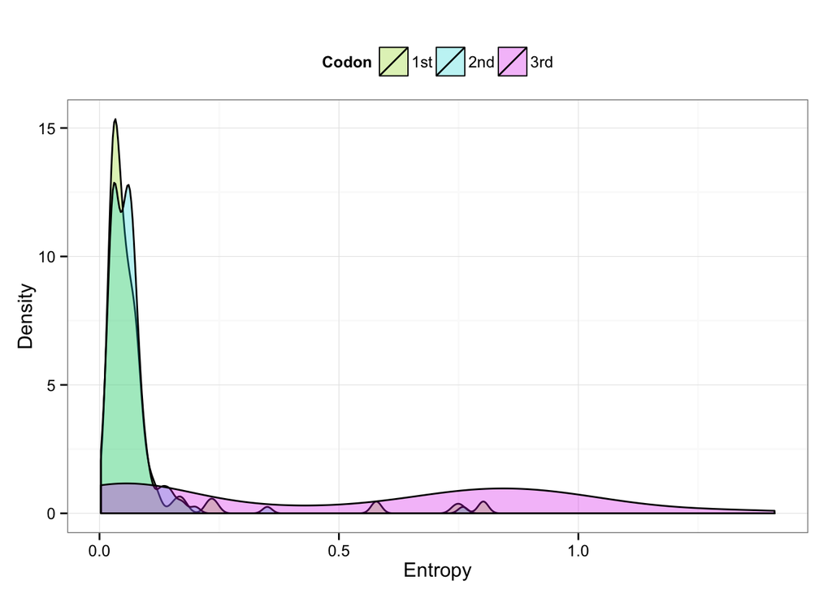

```r
entropy_plot
```

The resulting plot shows that the 3rd codon position has higher entropy values suggesting that if we use this aligment as input for the MED it could result in a possible overestimation of the diversity.

Next step is to know if the higher entropy values implies a real change in the aminoacid sequence or are silent substitution. We will use a saturation plot to explore the transitions and transversions ratio. As the NGS datasets that can be used for MED are really large, in this example we will pick 500 random sequences for the analysis (we recommend to use 5000 sequences aprox). For the distance calculation we use the *Kimura’s 2-parameters distance* (K80). We set all = FALSE because we only want to focus on the 3rd codon position, we can calculate the ratio for all codon positions with ALL = TRUE.

```r
saturation_plot <- plot_saturation(aln, nseqs = 500, model = "K80", all = FALSE )
```

```
## Note: A random seed has been selected
## Seed used: 8032849
## Randomly selected 500 sequences
##
## Sequence alignment cointaining only the 3rd codon position
## Calculating the number of pairwise transitions and transversions
## Computing matrix of pairwise distances using model K80
## Calculating statistics
## Drawing saturation plot
## Results suggests that there is saturation
## Removing 3rd codon position to the alignment
## Note: Substitution saturation occurs when the frequency of transitions (mean:22.81) overtakes the frequency of transversions (mean:11.95)
```

We can visually inspect the plot:

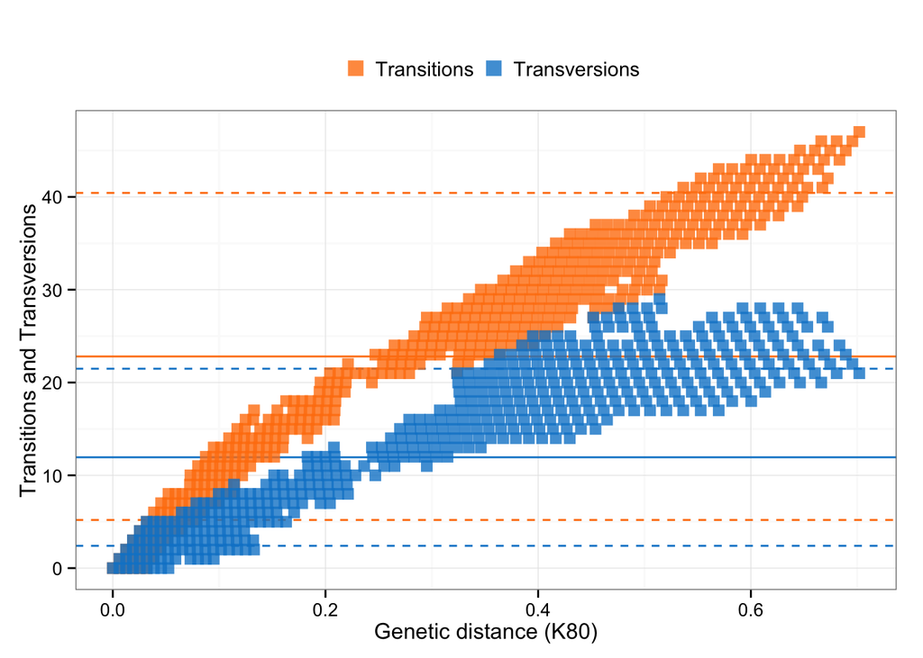

```r
saturation_plot$plot
```

Get some statistics:

```r
saturation_plot$stats
```

```
## $mean_ti
## [1] 22.80937
##
## $sd_ti
## [1] 17.61921
##
## $mean_tv
## [1] 11.94645
##
## $sd_tv
## [1] 9.540304
```

Or get the alignment without the 3rd codon position that can be used for the MED analysis:

```r
saturation_plot$aln_no_3rd
```

```
## 361890 DNA sequences in binary format stored in a matrix.
##
## All sequences of same length: 322
##
## Labels: Sample-101_Read10 Sample-101_Read19 Sample-101_Read55 Sample-101_Read72 Sample-101_Read90 Sample-101_Read105 ...
##
## More than 1 million nucleotides: not printing base composition
```

But using only 500 or 5000 sequences is not enough to be sure that there is no substitution saturation in our alignment. In this case one can use the function **plot_saturation_n** to perform n random subsamplings to the main alignment file. An example using the sequential version with performing 10 random subsamplings of 500 sequences:

[output not shown]

For a real world analysis we would perform at least 100 random subsamplings of >5000 sequences. The parallel version uses https://github.com/tudo-r/BatchJobs to distribute the different random subsamplings over multiple cores or a computer cluster. An example using the different cores of a computer:

```r
random_saturation_plots <- plot_saturation_n(aln, rep = 10, nseqs = 500, model = "K80", parallel = TRUE, all = FALSE, conf_file = "~/.BatchJobs.R", reg_id = "rhodo", reg_dir = "~/rhodo_dir")
```

```
## Creating dir: ~/rhodo_dir
```

```
## Sourced 3 configuration files:
```

```
##   1: /Library/Frameworks/R.framework/Versions/3.2/Resources/library/BatchJobs/etc/BatchJobs_global_config.R
```

```
##   2: /Users/ufo/.BatchJobs.R
```

```
##   3: /Users/ufo/Downloads/.BatchJobs.R
```

[output not shown]

```
## Saving registry: /Users/ufo/rhodo_dir/registry.RData
```

```
## Adding 10 jobs to DB.
```

```
## Saving conf: /Users/ufo/rhodo_dir/conf.RData
```

```
## Submitting 10 chunks / 10 jobs.
```

```
## Cluster functions: Multicore.
```

```
## Auto-mailer settings: start=none, done=none, error=none.
```

```
## Sending 10 submit messages...
## Might take some time, do not interrupt this!
```

[output not shown]

```
## Syncing registry ...
```

```
## Reducing 10 results...
```

> For reproducibility purposes, all seeds used by **plot_saturation** and **plot_saturation_n** are stored in the object returned under **seed**.

The contents of the .BatchJobs.R file:

```r
cluster.functions = makeClusterFunctionsMulticore(ncpus = max(getOption("mc.cores", parallel::detectCores()) - 1L, 1L))
staged.queries = TRUE
debug = FALSE
```

You can find examples for other queue managers [here](https://github.com/tudo-r/BatchJobs/tree/master/examples/). For example, if our cluster uses SGE, our **.tmpl** file should be similar to this [here](https://github.com/tudo-r/BatchJobs/blob/master/examples/cfSGE/simple.tmpl) and the .BatchJobs.R file should contain:

```r
cluster.functions = makeClusterFunctionsSGE("simple.tmpl")
staged.queries = TRUE
debug = FALSE
```

Once we got the results we can explore the object returned. We can explore the combined statistics:

```r
random_saturation_plots$combined_stats
```

```
## Source: local data frame [10 x 4]
##
##     mean_ti    sd_ti  mean_tv    sd_tv
##       (dbl)    (dbl)    (dbl)    (dbl)
## 1  22.82212 17.77880 11.90642 9.766385
## 2  22.54802 17.17006 11.96484 9.535445
## 3  23.54579 17.03588 12.49842 9.392668
## 4  22.51292 17.36567 11.84640 9.527419
## 5  22.06009 17.62117 11.53434 9.654497
## 6  23.38513 17.04374 12.36826 9.421417
## 7  23.34964 17.79702 12.27476 9.746335
## 8  21.48046 17.40790 11.41739 9.536055
## 9  20.74236 17.57762 10.83424 9.648948
## 10 23.35260 17.35144 12.23790 9.452513
```

Or we can look at the distribution of the average values for transitions and transversion for all random subsamplings:

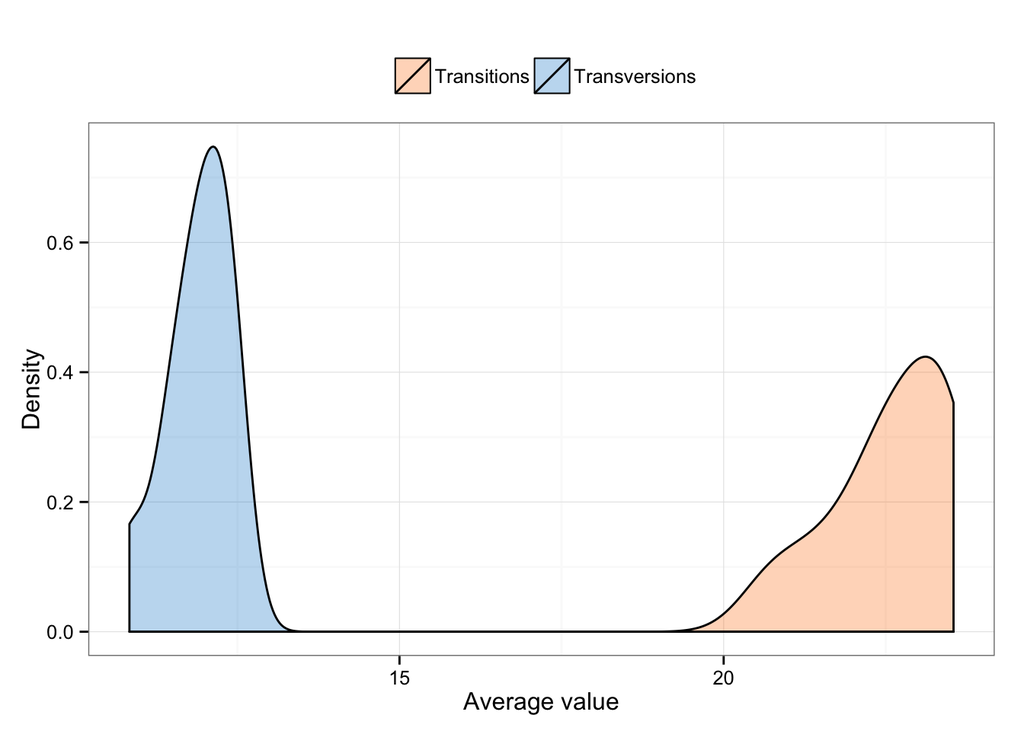

```
## Plots written to  ~/saturation_test_alignment_density_022920162223.pdf
```

```r
write_saturation_plot_density(random_saturation_plots, dir = "~", format = "pdf", show = TRUE)
```

This plot also suggests that there are more transitions than transversions so would be recommendable to remove the 3rd codon position from the alignment.

We can easily do this:

```r
write_saturation_alignments(random_saturation_plots, dir = "~", no3rd = TRUE)
```

```
## Alignmet(s) written to  ~/saturation_test_alignment_no3rd_022920162223.fasta
```

We can save all plots in disk:

```r
write_saturation_plots(random_saturation_plots, dir = "~", format = "pdf")
```

```
## Plot(s) written to  ~
```

And all random alignments used:

```r
write_saturation_alignments(random_saturation_plots, dir = "~")
```

```
## Alignmet(s) written to  ~
```

After all this steps we can use the exported alignment for the [MED](http://merenlab.org/projects/med/) analysis.